# P4: Explore and Sumarize Data

# Bivariate Plots Section

> It might be interesting a lot of correlations. As we have 12 variables we will try with several combinations.

We will start the bivariate section with a correlation analysis that can help us to decide which features are more likely to have a relation.

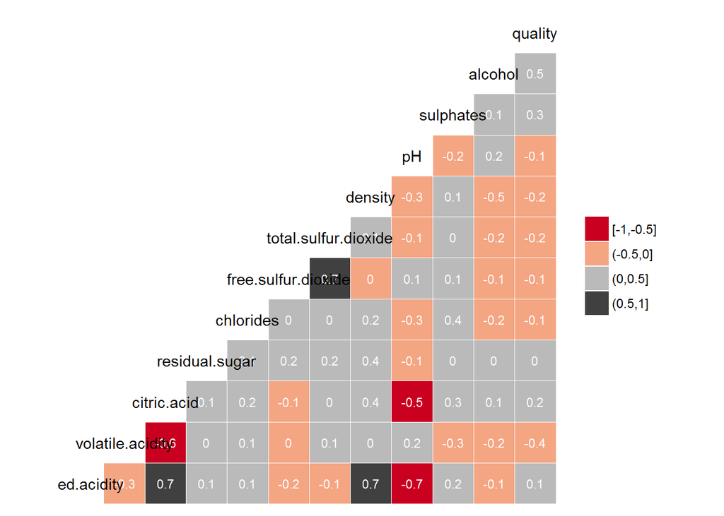

As we can see on the above plot, the feature with most correlation are free. sulfur.dioxide-total.sulfur.dioxide, fixed.acidity-citrid.acid, fixed.acidity-pH and density-dixed.acidity.

Along this analysis we will try to focus on the features, but we will study other features as well. We weill start with a scatter plot comparing the features with the highest grade of correlation.

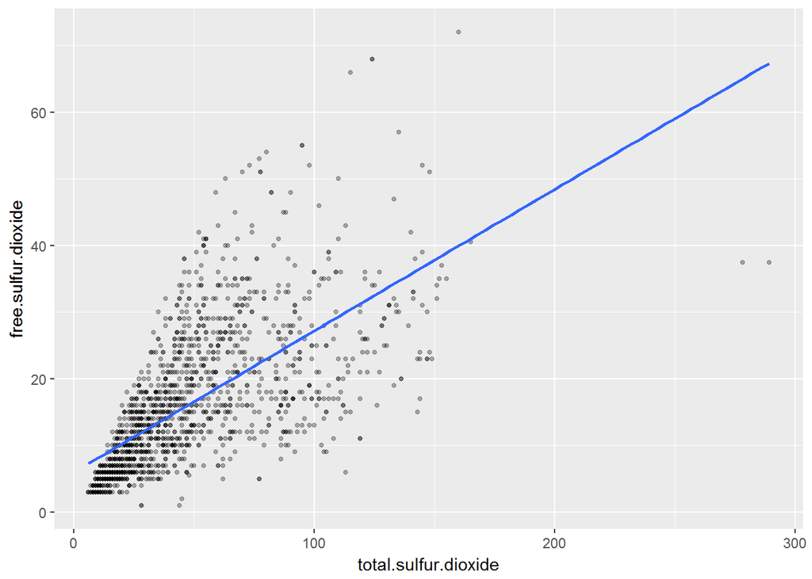

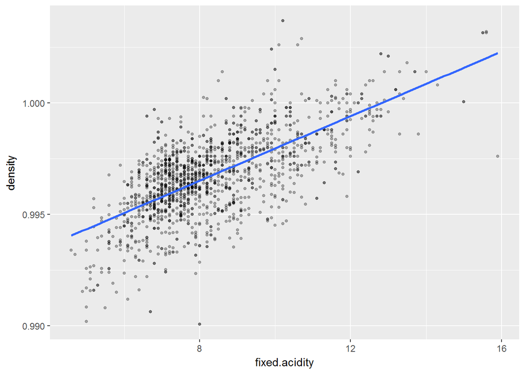

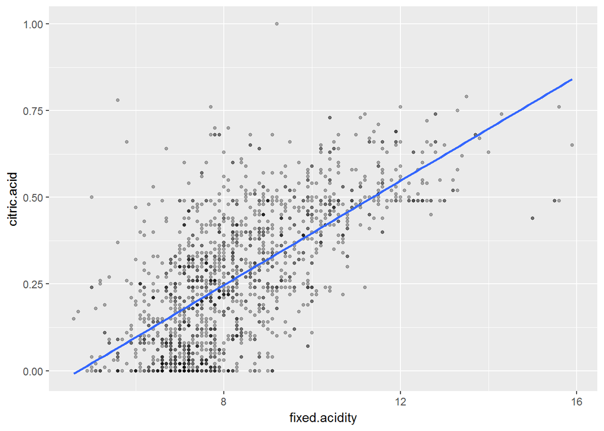

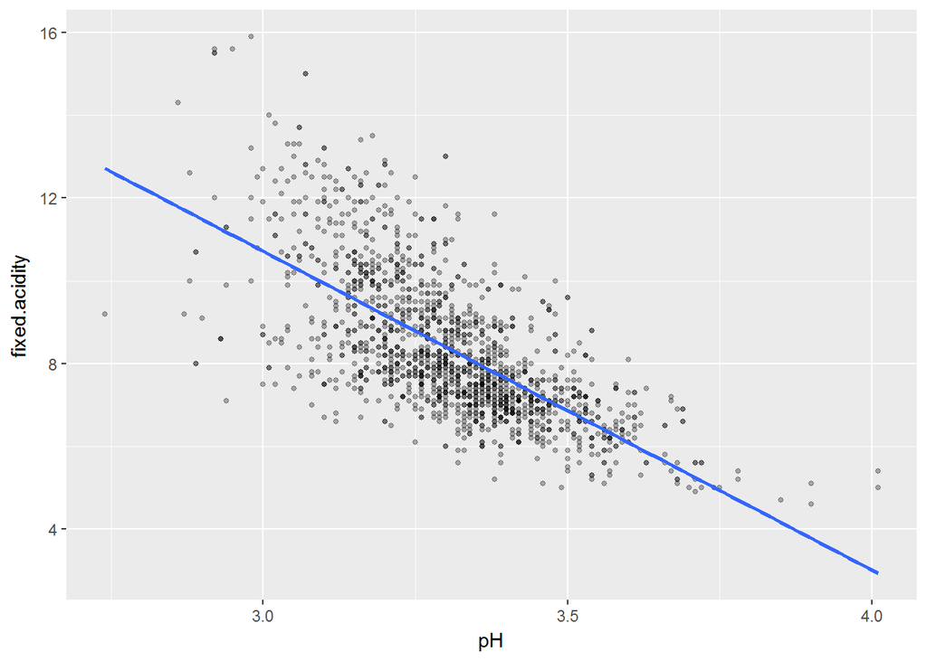

I displayed four graphs showing the relation between 2 variables. We can see easily a correlation between all the features compared.